# Assignment1-VIS

Megan Willis-Jackson

9/16/2020

# Visualizing Relationships and Distributions

First I will load the libraries necessary to run the code that follows.

```r
library(tidycensus)
library(tidyverse)
library(ggplot2)
```

Next, I will examine area- and person-level census variables to select those I would like to include in my dataset.

```r
area_vars_2018 <- load_variables(2018,"acs1")
person_vars_2018 <- pums_variables %>%
  distinct(year, survey, var_code,
           var_label, data_type, level) %>%
  filter(level == "person", year == 2018, survey == "acs1")
```

I have decided that I will derive the below variables at the census tract level for Brooklyn, NY (Kings County). Some of them might seem repetitive, but I think they will allow for some more interesting and varied comparisons later on.

## Variables to be Derived for Each Tract:

1. Percent white (continuous)
2. Percent black (continuous)
3. Percent non-white (continuous)
4. Majority Non-White (categorical)
5. Median income (continuous)
6. Median age (continuous)
7. Country of ancestry most common in the tract (categorical)

```r
#select all variables to be used in an area-
#level analysis

race_vars<- c(race_total = "B02001_001",
              white = "B02001_002",
              black = "B02001_003")

ancestry_vars<- c(Afghan = "B04006_002",
                   Albanian = "B04006_003",
                   Alsatian = "B04006_004",
                   American = "B04006_005",
                   Arab = "B04006_006",
                   ArabEgyptian = "B04006_007",
                   ArabIraqi = "B04006_008",
                   ArabJordanian = "B04006_009",
                   ArabLebanese = "B04006_010",
                   ArabMoroccan = "B04006_011",
                   ArabPalestinian = "B04006_012",
                   ArabSyrian = "B04006_013",
                   ArabArab = "B04006_014",
                   ArabOtherArab = "B04006_015",
                   Armenian = "B04006_016",
                   AssyrianChaldeanSyriac = "B04006_017",
                   Australian = "B04006_018",
                   Austrian = "B04006_019",
                   Basque = "B04006_020",
                   Belgian = "B04006_021",
                   Brazilian = "B04006_022",
                   British = "B04006_023",
                   Bulgarian = "B04006_024",
                   Cajun = "B04006_025",
                   Canadian = "B04006_026",
                   CarpathoRusyn = "B04006_027",
                   Celtic = "B04006_028",
                   Croatian = "B04006_029",
                   Cypriot = "B04006_030",
                   Czech = "B04006_031",
                   Czechoslovakian = "B04006_032",
                   Danish = "B04006_033",
                   Dutch = "B04006_034",
                   EasternEuropean = "B04006_035",
                   English = "B04006_036",
                   Estonian = "B04006_037",
                   European = "B04006_038",
                   Finnish = "B04006_039",
                   FrenchexceptBasque = "B04006_040",
                   FrenchCanadian = "B04006_041",
                   German = "B04006_042",
                   GermanRussian = "B04006_043",
                   Greek = "B04006_044",
                   Guyanese = "B04006_045",
                   Hungarian = "B04006_046",
                   Icelander = "B04006_047",
                   Iranian = "B04006_048",
                   Irish = "B04006_049",
                   Israeli = "B04006_050",
                   Italian = "B04006_051",
                   Latvian = "B04006_052",
                   Lithuanian = "B04006_053",
                   Luxembourger = "B04006_054",
                   Macedonian = "B04006_055",
                   Maltese = "B04006_056",
                   NewZealander = "B04006_057",
                   NorthernEuropean = "B04006_058",
                   Norwegian = "B04006_059",
                   PennsylvaniaGerman = "B04006_060",
                   Polish = "B04006_061",
                   Portuguese = "B04006_062",
                   Romanian = "B04006_063",
                   Russian = "B04006_064",
                   Scandinavian = "B04006_065",
                   Scotch_Irish = "B04006_066",
                   Scottish = "B04006_067",
                   Serbian = "B04006_068",
                   Slavic = "B04006_069",
                   Slovak = "B04006_070",
                   Slovene = "B04006_071",
                   SovietUnion = "B04006_072",
                   SubsaharanAfrican = "B04006_073",
                   SubsaharanAfricanCapeVerdean = "B04006_074",
                   SubsaharanAfricanEthiopian = "B04006_075",
                   SubsaharanAfricanGhanaian = "B04006_076",
                   SubsaharanAfricanKenyan = "B04006_077",
                   SubsaharanAfricanLiberian = "B04006_078",
                   SubsaharanAfricanNigerian = "B04006_079",
                   SubsaharanAfricanSenegalese = "B04006_080",
                   SubsaharanAfricanSierraLeonean = "B04006_081",
                   SubsaharanAfricanSomali = "B04006_082",
                   SubsaharanAfricanSouthAfrican = "B04006_083",
                   SubsaharanAfricanSudanese = "B04006_084",
                   SubsaharanAfricanUgandan = "B04006_085",
                   SubsaharanAfricanZimbabwean = "B04006_086",
                   SubsaharanAfricanAfrican = "B04006_087",
                   SubsaharanAfricanOtherSubsaharanAfrican = "B04006_088",
                   Swedish = "B04006_089",
                   Swiss = "B04006_090",
                   Turkish = "B04006_091",
                   Ukrainian = "B04006_092",
                   Welsh = "B04006_093",
                   WestIndianexceptHispanicgroups = "B04006_094",
                   WestIndianexceptHispanicgroupsBahamian = "B04006_095",
                   WestIndianexceptHispanicgroupsBarbadian = "B04006_096",
                   WestIndianexceptHispanicgroupsBelizean = "B04006_097",
                   WestIndianexceptHispanicgroupsBermudan = "B04006_098",
                   WestIndianexceptHispanicgroupsBritishWestIndian = "B04006_099",
                   WestIndianexceptHispanicgroupsDutchWestIndian = "B04006_100",
                   WestIndianexceptHispanicgroupsHaitian = "B04006_101",
                   WestIndianexceptHispanicgroupsJamaican = "B04006_102",
                   WestIndianexceptHispanicgroupsTrinidadianandTobagonian = "B04006_103",
                   WestIndianexceptHispanicgroupsU.S.VirginIslander = "B04006_104",
                   WestIndianexceptHispanicgroupsWestIndian = "B04006_105",
                   WestIndianexceptHispanicgroupsOtherWestIndian = "B04006_106",
                   Yugoslavian = "B04006_107")
                   #Othergroups = "B04006_108",
                   #Unclassifiedornotreported = "B04006_109")
```

I exclude “Other groups” and “Unclassified or not reported” responses from this analysis simply because I would like to have more specificity in the charts. Ideally, I would code the count of each individual ancestry country and present those distributions, but that is likely something more easily done at the county level instead of comparing across tracts, particularly with the scope of this assignment.

```r
income_var<- c(median_income = "B06011_001")

age_var<- c(median_age = "B01002_001")


income_data<- get_acs(geography = "tract",
                   variables = income_var,
                   output = "wide",
                   state = "NY",
                   county = "Kings",
                   year = 2018)
age_data<- get_acs(geography = "tract",
                   variables = age_var,
                   output = "wide",
                   state = "NY",
                   county = "Kings",
                   year = 2018)
race_data<- get_acs(geography = "tract",
                    variables = race_vars,
                    output = "wide",
                    state = "NY",
                    county = "Kings",
                    year = 2018)

ancestry_type_data<- get_acs(geography = "tract",
                             variables = ancestry_vars,
                             state = "NY",
                             county = "Kings",
                             year = 2018)

#sort the ancestry country data first by tract (GEOID), then by the highest population reporting
ancestry_type_data<- ancestry_type_data[order(ancestry_type_data[,1],-ancestry_type_data[,4]),]

#select the highest reported ancestry country population for each tract
maj_ancestry<-   ancestry_type_data %>%
  group_by(GEOID) %>%
  summarise(maj_anc_pop = max(estimate),maj_anc_type = first(variable)) %>%
  select(GEOID, maj_anc_pop, maj_anc_type)

#combine variables into one dataset
kings_data<- inner_join(race_data, age_data, by = "GEOID") %>%
  mutate(pct_white = whiteE / race_totalE,
         pct_black = blackE / race_totalE,
         pct_not_white = (race_totalE - whiteE) / race_totalE,
         majority_not_white = pct_not_white > .5) %>%
  select(GEOID, pct_white, pct_black, pct_not_white, majority_not_white, median_ageE)

kings_data<- inner_join(kings_data, income_data, by = "GEOID") %>%
  select(GEOID, pct_white, pct_black, pct_not_white, majority_not_white, median_ageE, median_incomeE)

kings_data<- inner_join(kings_data, maj_ancestry, by = "GEOID") %>%
  #group ancestry types more generally
  mutate(maj_anc_group = case_when(
    maj_anc_type == "Russian" ~ "Europe",
    maj_anc_type == "Polish" ~ "Europe",
    maj_anc_type == "Hungarian" ~ "Europe",
    maj_anc_type == "EasternEuropean" ~ "Europe",
    maj_anc_type == "Ukrainian" ~ "Europe",
    maj_anc_type == "Turkish" ~ "Europe",
    maj_anc_type == "Serbian" ~ "Europe",
    maj_anc_type == "European" ~ "Europe",
    maj_anc_type == "Arab" ~ "Middle East",
    maj_anc_type == "Afghan" ~ "Middle East",
    maj_anc_type == "Norwegian" ~ "Europe",
    maj_anc_type == "Guyanese" ~ "South America",
    maj_anc_type == "Italian" ~ "Europe",
    maj_anc_type == "Greek" ~ "Europe",
    maj_anc_type == "SubsaharanAfrican" ~ "Sub-Saharan Africa",
    maj_anc_type == "American" ~ "United States",
    maj_anc_type == "WestIndianexceptHispanicgroups" ~ "West Indies",
    maj_anc_type == "German" ~ "Europe",
    maj_anc_type == "Irish" ~ "Europe",
    maj_anc_type == "English" ~ "Europe",
    maj_anc_type == "Belgian" ~ "Europe")) %>%
  select(GEOID, pct_white, pct_black, pct_not_white, majority_not_white, median_ageE, median_incomeE, maj_anc_type, maj_anc_group)
```

#### Save File as CSV

```r
write_csv(kings_data,"king_county.csv")
```

## Visualize the Data

### Graph 1

The colors here probably aren’t very helpful, as it only really adds additional information for the Europe category, and even then it’s hard to make out the fine details.

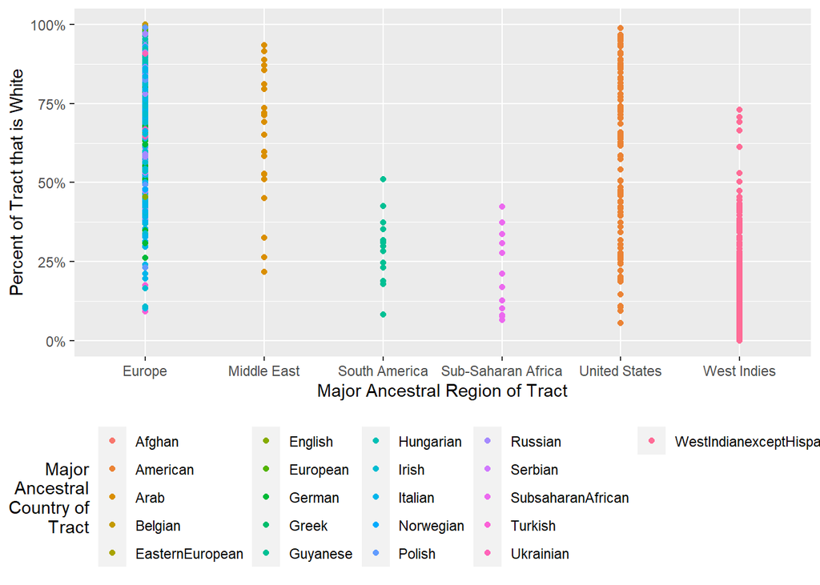

```r
attach(kings_data)

ggplot(kings_data,
       aes(x = maj_anc_group,
           y = pct_white,
           color = maj_anc_type)) +
  geom_point(na.rm = T) +
  scale_x_discrete(name = "Major Ancestral Region of Tract") +
  scale_y_continuous(name = "Percent of Tract that is White",
                     breaks = seq(0,1, by = .25),
                     labels = c("0%","25%","50%","75%","100%")) +
  scale_color_discrete(name = "Major\n Ancestral\n Country of\n Tract", ) +
  theme(legend.position = "bottom", legend.title.align = 1)
```

### Graph 2

I try a pretty standard pie chart below.

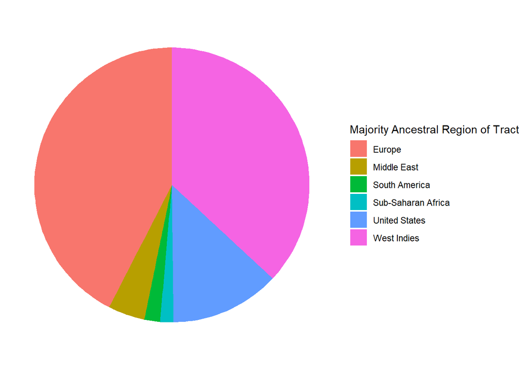

```r
ggplot(kings_data,
       aes(x = 1, fill = maj_anc_group)) +
  geom_bar(position = "fill") +
  coord_polar(theta = "y") +
  scale_y_continuous(name = "Number of tracts") +
  scale_fill_discrete(name = "Majority Ancestral Region of Tract") +
  theme_void()
```

### Graph 3

This is not a graph I would ever include in a report or any official communications. There are far too many variables for it to be useful or even particularly legible. However, I do think it’s fun to play around with visualizations like this, so I’m going for it!

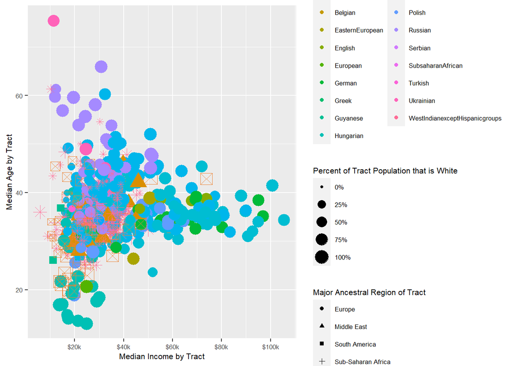

```r
ggplot(kings_data,
       aes(x = median_incomeE,
           y = median_ageE,
           size = pct_white,
           shape = maj_anc_group,
           color = maj_anc_type)
       ) +
  geom_point(na.rm = T) +
  theme(legend.position = "right", text = element_text(size = 8)) +
  scale_x_continuous(name = "Median Income by Tract",
                     breaks = seq(0, 100000, by = 20000),
                     labels = c("$0", "$20k", "$40k", "$60k", "$80k", "$100k")) +
  scale_y_continuous(name = "Median Age by Tract")+
  scale_shape_discrete(name = "Major Ancestral Region of Tract")+
  scale_color_discrete(name = "Major Ancestral Country of Tract")+
  scale_size_continuous(name = "Percent of Tract Population that is White",
                        breaks = c(0.0, .25, .5, .75, 1),
                        labels = c("0%", "25%", "50%", "75%", "100%")) +
  theme(text = element_text(size = 8))
```

### Graph 4

The following two graphs are very similar so I am counting them as the same. The only difference is inclusion of color, which I think adds clarity to it in some ways but detracts in others. For example, the color demonstrates which tracts with certain ancestral countries are the only ones to make higher than a certain median income. The one without color, however, better shows that the most variance is seen in tracts where the median age is between about 30 and 45 years.

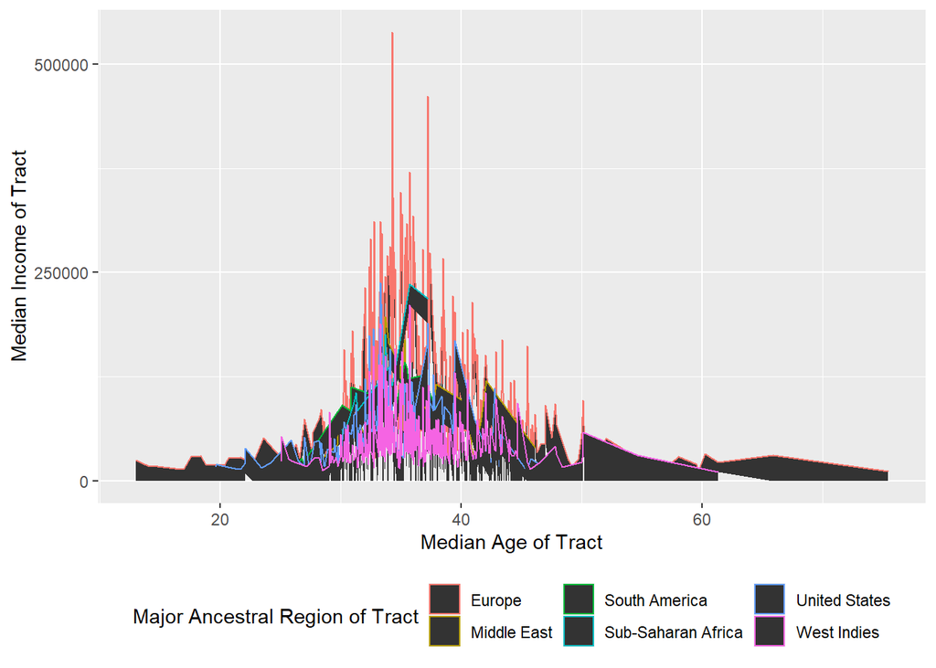

```r
ggplot(kings_data,
       aes(x = median_ageE,
           y = median_incomeE,
           color = maj_anc_group)) +
  geom_area(na.rm = T) +
  scale_x_continuous(name = "Median Age of Tract") +
  scale_y_continuous(name = "Median Income of Tract",
                     breaks = seq(0, 1000000, by = 250000)) +
  scale_color_discrete(name = "Major Ancestral Region of Tract") +
  theme(legend.position = "bottom")
```

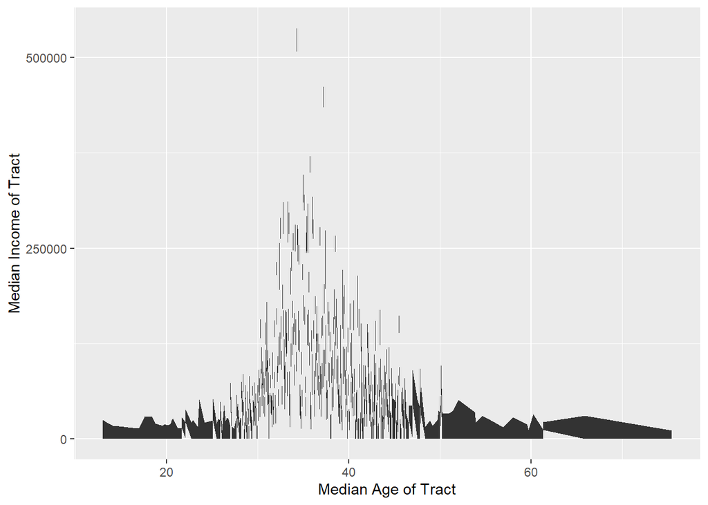

```r
ggplot(kings_data,
       aes(x = median_ageE,
           y = median_incomeE)) +
  geom_area(na.rm = T) +
  scale_x_continuous(name = "Median Age of Tract") +
  scale_y_continuous(name = "Median Income of Tract",
                     breaks = seq(0, 1000000, by = 250000))
```

### Graph 5

The point graph below shows the relationship between the percentage of a tract in Kings County that is not white and that tract’s median income.

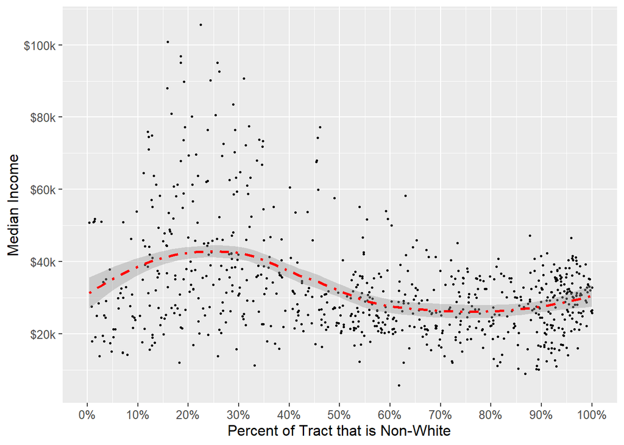

```r
ggplot(kings_data,
       aes(x = pct_not_white,
           y = median_incomeE)) +
  geom_point(alpha = 1, size = 0.5) +
  stat_smooth(color = "red", linetype = 4, size = 1) +
  scale_x_continuous(name = "Percent of Tract that is Non-White",
                     breaks = seq(0,1,.1),
                     labels = c("0%","10%","20%","30%","40%","50%","60%","70%","80%","90%","100%")) +
  scale_y_continuous(name = "Median Income",
                     breaks = seq(0,100000,by = 20000),
                     labels = c("$0","$20k","$40k","$60k","$80k","$100k")) +
  theme(text = element_text(size = 12))
```

### Graph 6

This is a stacked bar chart, grouping each of the Brooklyn tracts by majority ancestral region, and then within that, breaking out the specific ancestral country.

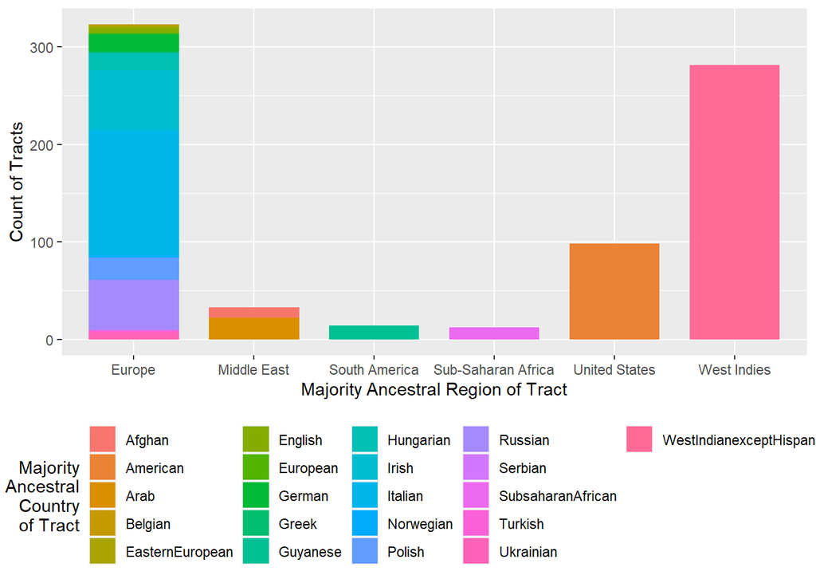

```r
ggplot(kings_data,
       aes(x = maj_anc_group, fill = maj_anc_type)) +
  geom_bar(width = .75, na.rm = T) +
  scale_x_discrete(name = "Majority Ancestral Region of Tract") +
  scale_y_continuous(name = "Count of Tracts") +
  theme(legend.position = "bottom", legend.title.align = 1) +
  scale_fill_discrete(name = "Majority\n Ancestral\n Country\n of Tract")
```

### Graph 7

This scatter plot also may have a bit too much on it to be truly helpful. A more useful graph would probably remove the shape distinctions and make the colors ancestral regions as opposed to ancestral countries so that the distinctions are easier to see. Here, though, the chart suggests that in Brooklyn, it is mostly tracts with residents that are largely of European descent (specifically Irish and Italian) that even have median incomes over about $60k.

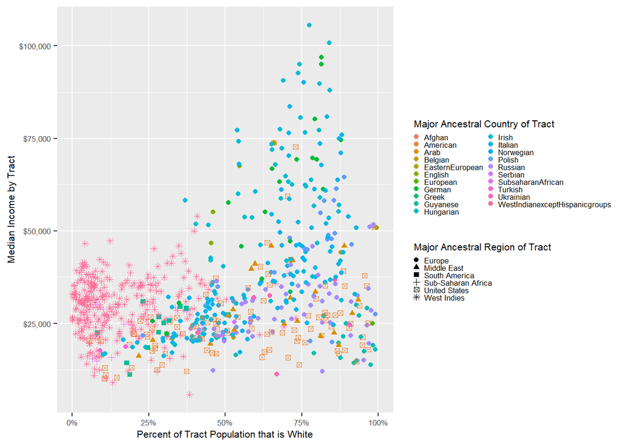

```r
ggplot(kings_data,
       aes(x = pct_white,
           y = median_incomeE,
           color = maj_anc_type,
           shape = maj_anc_group
            )) +
  geom_point(na.rm = T) +
  scale_x_continuous(name = "Percent of Tract Population that is White",
                     breaks = c(0.0, .25, .5, .75, 1),
                     labels = c("0%", "25%", "50%", "75%", "100%")) +
  scale_y_continuous(name = "Median Income by Tract",
                     breaks = c(25000,50000,75000,100000),
                     labels = c("$25,000","$50,000","$75,000","$100,000")) +
  scale_shape_discrete(name = "Major Ancestral Region of Tract") +
  scale_color_discrete(name = "Major Ancestral Country of Tract") +
  theme(legend.key.size = unit(0.1, "cm"),
        legend.position = "right",
        text = element_text(size = 8))
```

### Graph 8

I both like and dislike this graph. I would never use it in a report, but it’s also a bit intriguing to look at. I think it also does a decent job at illustrating what Graph 7 suggests: census tracts with residents of West Indies descent tend to make less that those of European descent.

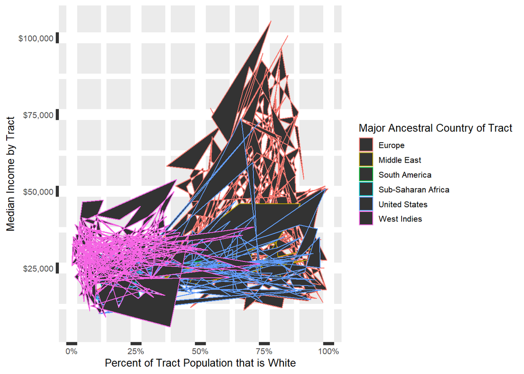

```r
ggplot(kings_data,
       aes(x = pct_white,
           y = median_incomeE,
           color = maj_anc_group,
            )) +
  geom_polygon(rule = "winding", na.rm = T) +
  scale_x_continuous(name = "Percent of Tract Population that is White",
                     breaks = c(0.0, .25, .5, .75, 1),
                     labels = c("0%", "25%", "50%", "75%", "100%")) +
  scale_y_continuous(name = "Median Income by Tract",
                     breaks = c(25000,50000,75000,100000),
                     labels = c("$25,000","$50,000","$75,000","$100,000")) +
  scale_shape_discrete(name = "Major Ancestral Region of Tract") +
  scale_color_discrete(name = "Major Ancestral Country of Tract") +
  theme(legend.key.size = unit(0.5, "cm"),
        line = element_line(size = 5),
        legend.position = "right",
        text = element_text(size = 10))
```

### Graph 9

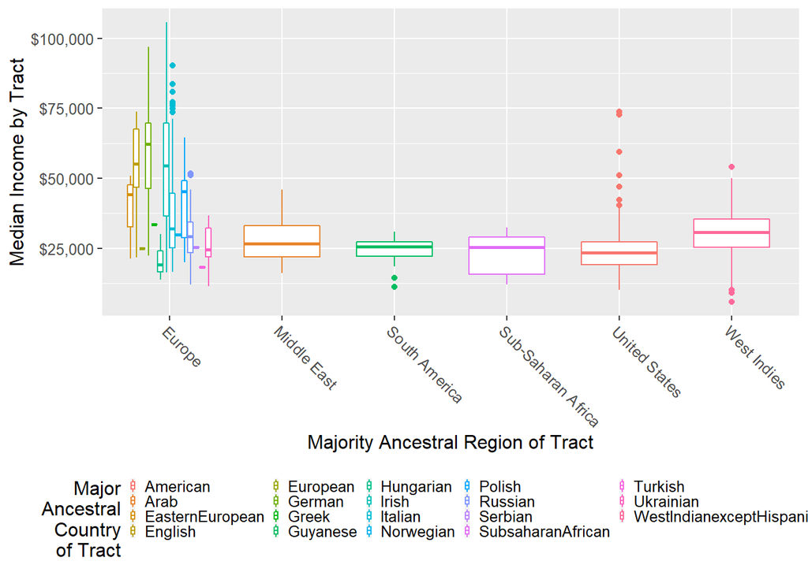

```r
ggplot(kings_data,
       aes(x = maj_anc_group,
           y = median_incomeE,
           color = maj_anc_type,
            )) +
  geom_boxplot(na.rm = T) +
  theme(legend.position = "bottom") +
  scale_x_discrete(name = "Majority Ancestral Region of Tract") +
  scale_y_continuous(name = "Median Income by Tract",
                     breaks = c(25000,50000,75000,100000),
                     labels = c("$25,000","$50,000","$75,000","$100,000")) +
  scale_color_discrete(name = "Major\n Ancestral\n Country\n of Tract") +
  theme(legend.key.size = unit(0.1, "cm"),
        text = element_text(size = 12),
        axis.text.x = element_text(angle = -45, hjust = 0),
        legend.title.align = 1)
```

### Graph 10

I like the simplicity of this scatter plot. It’s easy to interpret and doesn’t have too much going on that will distract the reader. Oldie-but-goodie.

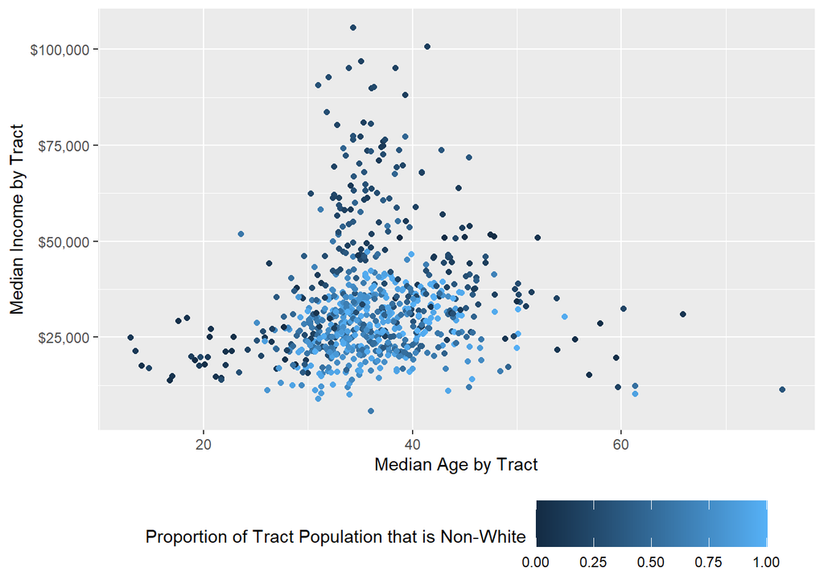

```r
ggplot(kings_data,
       aes(x = median_ageE,
           y = median_incomeE,
           color = pct_not_white)) +
  geom_point(show.legend = T, na.rm = T) +
  theme(legend.position = "bottom",
        legend.key.size = unit(1,"cm"))+
  scale_y_continuous(name = "Median Income by Tract",
                     breaks = c(25000,50000,75000,100000),
                     labels = c("$25,000","$50,000","$75,000","$100,000"))+
  scale_x_continuous(name = "Median Age by Tract")+
  scale_color_continuous(name = "Proportion of Tract Population that is Non-White")
```

[output not shown]